# Comb B Ising Model Coursework

This notebook uses the data extracted from the Ising Model that was made in C++ and shows the analysis from said data.

The Coursework was split into 5 questions:

Q1a - Calculating average magnetisation and how it changes with an increasing sweep number

Q1b - Calculating average energy and how it changes with an increasing sweep number

Q2 - Analysing how magnetisation and energy change when beta (inverse of temperature) increases

Q3 + 4 - Comparing data from a mean field approximation (MFA) with the data from the Ising Model

Q5 - Determining the relationship between the G_ij coefficient and the distance d between particles

## Question 1a

Calculating the average magnetisation of the Ising Model and its relationship to an increasing sweep number.

```python
#Importing needed libraries
import numpy as np
import pandas as pd
import matplotlib.pyplot as plt
```

```python
#Formatting function

def format(xlabel, ylabel):
    plt.xlabel(xlabel, fontname="Times New Roman", fontsize=12)
    plt.ylabel(ylabel, fontname="Times New Roman", fontsize=12)
    plt.rcParams["font.family"] = "Times New Roman"
    plt.xticks(fontname="Times New Roman")
    plt.yticks(fontname="Times New Roman")
    return
```

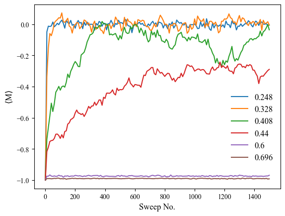

```python
#Reading in the data for Magnetisation at different temperatures
df_m = pd.read_table("C:\\Users\\euanc\\OneDrive - University of Bath\\Documents\\Work\\Final Year\\2nd semester\\CompB\\Ising Model\\Raw Data\\Mag1500.txt",
                    delimiter = ",", header = None, names= ["Beta", "Sweep no.", "M"])

b1 = [0.248, 0.328, 0.408, 0.44, 0.6, 0.696] #Beta values we want to look at

#Modified dataset, only shows sweep numbers that are a multiple of 10, starts from 0
df_mod_m = df_m[df_m["Sweep no."] % 10 == 0]
df_mod_m = df_mod_m.loc[df_m['Beta'].isin(b1)]

# Calculating the mean value for the magnetisation for each sweep number in a given beta value, then plotting
mean_m = df_mod_m.groupby(by=["Beta", "Sweep no."],
                          as_index=False).mean("M")

mean_m = mean_m.pivot(index='Sweep no.', columns='Beta', values='M').plot()
format("Sweep No.", r"$\langle$M$\rangle$")
plt.legend(b1, loc="right", bbox_to_anchor=(1, 0.33),
            frameon=False, fontsize=12)
```

## Question 1b

Calculating the average energy of the Ising Model and its relationship to an increasing sweep number.

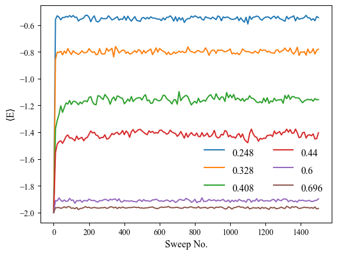

```python
df_e = pd.read_table(r"C:\Users\euanc\OneDrive - University of Bath\Documents\Work\Final Year\2nd semester\CompB\Ising Model\Raw Data\En1500.txt",
                     delimiter=",", header=None, names=["Beta", "Sweep no.", "E"])

# Same method as before, calculating average energy etc.
df_mod_e = df_e[df_e["Sweep no."] % 10 == 0]
df_mod_e = df_mod_e.loc[df_e['Beta'].isin(b1)]

mean_e = df_mod_e.groupby(by=["Beta", "Sweep no."],
                          as_index=False).mean("E")

mean_e = mean_e.pivot(index='Sweep no.', columns='Beta', values='E').plot()
format("Sweep No.", r"$\langle$E$\rangle$")
plt.legend(b1, loc="right", bbox_to_anchor=(1,0.24), ncol=2,
            handleheight=2.4, labelspacing=0.01, frameon=False, fontsize=12)
```

## Question 2

Using the same datasets to determine the relationship between the magnetisation/energy against beta

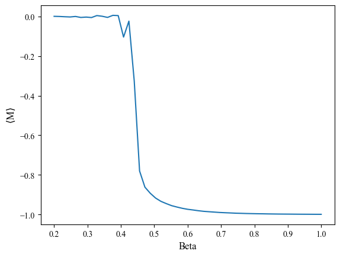

```python
#-------------Magnetisation-------------------------

df_m2 = df_m[df_m["Sweep no."] >= 400]
df_m2 = df_m2[(df_m2["Sweep no."]) % 10 == 0]

#Plotting average M against Beta
mag_b = df_m2.groupby(["Beta"])["M"].mean()
mag_b.plot()
format("Beta", r"$\langle$M$\rangle$")
```

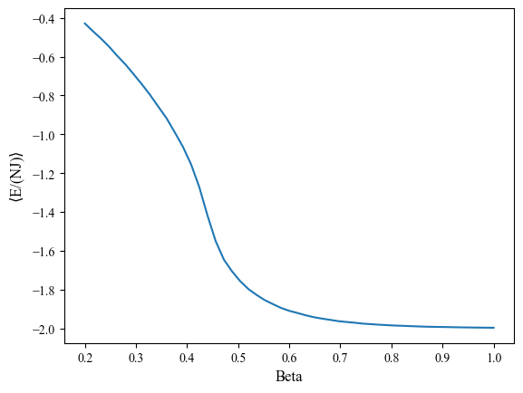

```python
df_e2 = df_e[df_e["Sweep no."] >= 70]
df_e2 = df_e2[(df_e2["Sweep no."]) % 10 == 0]

#Plotting average energy against beta
en_b = df_e2.groupby(["Beta"])["E"].mean()
en_b.plot()
format("Beta", r"$\langle$E/(NJ)$\rangle$")
```

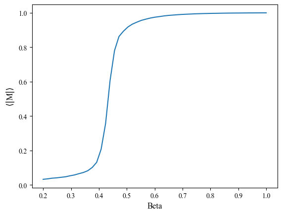

```python
df_ab =  df_m[df_m["Sweep no."] >= 400]
df_ab = df_ab[(df_ab["Sweep no."]) % 10 == 0].abs()
ab_m = df_ab.groupby(["Beta"])["M"].mean()
ab_m.plot()
format("Beta", r"$\langle$$\|$M$\|$$\rangle$")
```

Average absolute magnetism against beta, showing a sharp increase at the 0.44 mark (right around where the phase transition is)

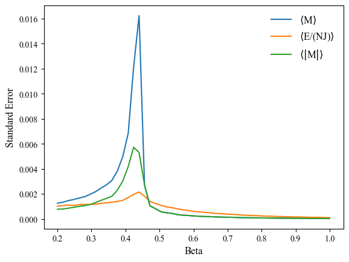

```python
# Error in E, M  and |M| against beta
m_err = df_m2.groupby(["Beta"])["M"].sem()
e2_err = df_e2.groupby(["Beta"])["E"].sem()
ab_m_err = df_ab.groupby(["Beta"])["M"].sem()

# List for legend
leg = [r"$\langle$M$\rangle$", r"$\langle$E/(NJ)$\rangle$",
       r"$\langle$$\|$M$\|$$\rangle$"]

# Plotting the three error trends
ax = m_err.plot(x='Beta', y='M')
e2_err.plot(ax=ax, x='Beta', y='E')
ab_m_err.plot(ax=ax, x='Beta', y='|M|')

# Formatting
format("Beta", "Standard Error")
plt.legend(leg, frameon=False, fontsize=12)
plt.show()
```

## Question 3

Comparing the MFA Data with the |M| and exact sinh values

```python
#MFA data
df_mfa = pd.read_table("MFAData.txt", delim_whitespace=True,
                   header=None, names=["T/T_c.", "m", "e", "c", "chi"])
```

```python
#Approx. sinh models
def mPos(B):
    return (1 - (1/((np.sinh(2 * B))**4)))**(1/8)


def mNeg(B):
    return -(1 - (1/((np.sinh(2 * B))**4)))**(1/8)
```

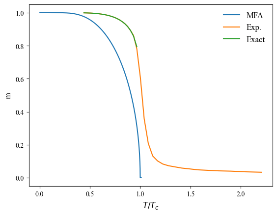

```python
x = np.linspace(0.2, 1, 51)
T = 1/(x)

plt.plot(df_mfa["T/T_c."], df_mfa["m"])
plt.plot(T/2.269, ab_m)
plt.plot(T/2.269, mPos(1/(T)))
format(r"$T/T_c$", "m")
plt.legend(["MFA", "Exp.", "Exact"], frameon=False, fontsize=12)
plt.show()
```

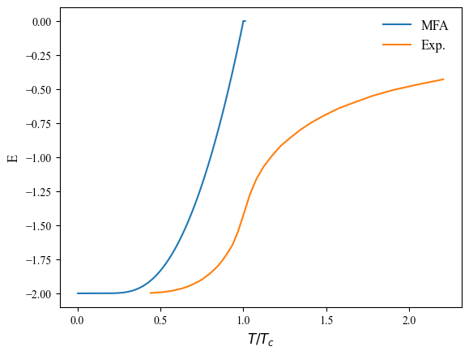

```python
plt.plot(df_mfa["T/T_c."], df_mfa["e"])
plt.plot(T/2.269, en_b)
format(r"$T/T_c$", "E")
plt.legend(["MFA", "Exp."], frameon=False, fontsize=12)
plt.show()
```

## Question 4

```python
#M^2
df_m["M**2"] = df_m["M"]**2

mean_m = df_m.groupby(["Beta"])["M"].mean()
mean_m_sq = df_m.groupby(["Beta"])["M**2"].mean()
m_err = df_m2.groupby(["Beta"])["M"].sem()
m_sq_error = df_m.groupby(["Beta"])["M**2"].sem()



var_m = mean_m_sq - (mean_m**2)
var_m = var_m * (1600*2.269)

var_m_err = m_sq_error + (2*m_err)
```

```python
#E^2
df_e["E**2"] = df_e["E"]**2

mean_e = df_e.groupby(["Beta"])["E"].mean()
mean_e_sq = df_e.groupby(["Beta"])["E**2"].mean()
e_err = df_e2.groupby(["Beta"])["E"].sem()
e_sq_err = df_e.groupby(["Beta"])["E**2"].sem()

var_e = mean_e_sq - (mean_e**2)
var_e = var_e * 1600/2.27

var_e_err = (2*e_err) + e_sq_err
```

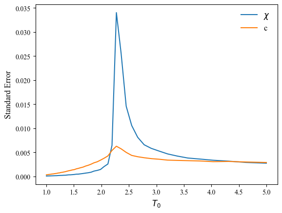

```python
plt.plot(T, var_m_err)
plt.plot(T, var_e_err)
format(r"$T_0$", "Standard Error")
plt.legend([r"$\chi$", "c"], frameon=False, fontsize=12)
plt.show()
```

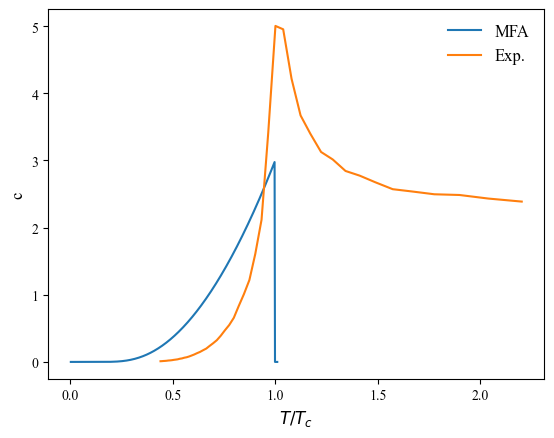

```python
plt.plot(df_mfa["T/T_c."], df_mfa["c"])
plt.plot(T/2.27, var_e)
format(r"$T/T_c$", "c")
plt.legend(["MFA", "Exp."], frameon=False, fontsize=12)
plt.show()
```

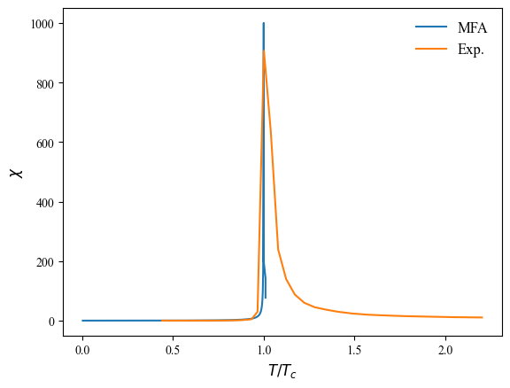

```python
plt.plot(df_mfa["T/T_c."], df_mfa["chi"])
plt.plot(T/2.27, var_m)
format(r"$T/T_c$", r"$\chi$")
plt.legend(["MFA", "Exp."], frameon=False, fontsize=12)
plt.show()
```

## Question 5

```python
df_g = pd.read_table(r"C:\Users\euanc\OneDrive - University of Bath\Documents\Work\Final Year\2nd semester\CompB\Ising Model\Raw Data\CorrFinal.txt",
                    delimiter=",", header=None,
                    names=["Beta", "Sweep no.", "G(21, 20)", "G(21, 25)", "G(21, 39)", "G(21, 15)", "G(21, 1)"])
df_g = df_g[(df_g["Sweep no."] >= 75)]
```

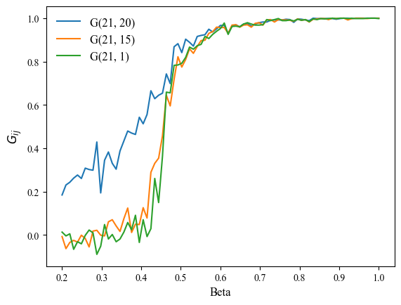

```python
coords = ["G(21, 20)",  "G(21, 25)",  "G(21, 39)",  "G(21, 15)",  "G(21, 1)"]
g_ij = df_g.groupby(["Beta"])[coords].mean()

b2 = np.linspace(0.2, 1, 83)

plt.plot(b2, g_ij["G(21, 20)"])
plt.plot(b2, g_ij["G(21, 15)"])
plt.plot(b2, g_ij["G(21, 1)"])
format("Beta", r"$G_{ij}$")
plt.legend(["G(21, 20)", "G(21, 15)", "G(21, 1)"], frameon=False, fontsize=12)
plt.show()
```

```python
df_g2 = pd.read_table(r"C:\Users\euanc\OneDrive - University of Bath\Documents\Work\Final Year\2nd semester\CompB\Ising Model\Raw Data\CorrDistB02.txt",
                   delimiter=",", header=None, names=["Beta", "Sweep", "d", "i", "j", "i*j"])

df_g2 = df_g2[(df_g2["Sweep"]) % 10 == 0]

#print(df_g2["i"])

av_i = df_g2.groupby(["d"])["i"].mean()
av_j = df_g2.groupby(["d"])["j"].mean()
av_g = df_g2.groupby(["d"])["i*j"].mean()

#display(av_i, av_j, av_g)
```

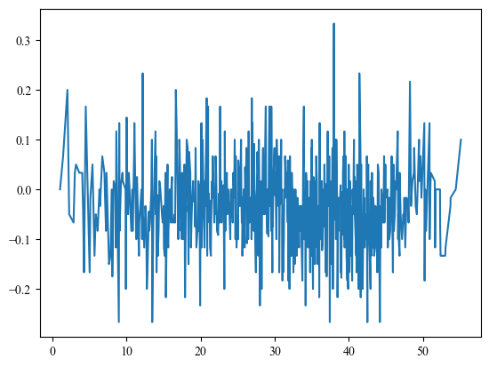

```python
d = df_g2["d"].unique()
d.sort()
plt.plot(d, av_j)
```

Don't think I wrote the code well for this question, the graph above isn't meant to look like this.